# **Urban_Logistic_Demand_Forecasting**

**Authored by**: Shivani Satav

**Duration:** 90 mins

**Level:** Intermediate

**Pre-requisite Skills:** Python, Pandas

**Scenario**

The city transport authority wants to optimise delivery routes and reduce congestion in urban areas. They have collected data from traffic sensors counting vehicles, specifically vans and trucks, at various locations across the city from 2023 to 2026.

By pinpointing periods of highest logistics demand and analysing trends over time, city authorities can make informed decisions regarding freight management, infrastructure development, and traffic regulation. Such understanding also supports optimised delivery scheduling and more efficient urban logistics operations throughout Melbourne.

**User Story**

As a city logistics planner, I want to analyse van and truck traffic across key locations and times, So that I can identify peak periods of activity and forecast future demand also reduce congestion, improve delivery efficiency. This insight will enable better planning of freight movement, transport infrastructure, and overall urban logistics operations.

**Introduction**

This document aims to explore urban logistics demand patterns in Melbourne by analysing van and truck traffic across the city over multiple years.

This analysis follows these main stages:

Data Collection – Importing traffic count datasets for vans and trucks from 2023 to 2026, including information on location, time, and vehicle counts.

Data Cleaning & Preprocessing – Renaming columns for clarity, filtering for relevant vehicle types (vans and trucks), converting timestamps to datetime format, and extracting time-based features such as hour, day, and year.

Exploratory Data Analysis (EDA) – Summarising and visualising logistics activity trends over time, identifying peak traffic hours, busiest days of the week, and top traffic locations.

Aggregation & Trend Analysis – Grouping data by year, location, and other relevant dimensions to observe growth patterns and hotspots in urban freight movement.

Visual Analysis – Using line charts, bar charts, and histograms to present traffic patterns and insights in an easily interpretable way.

The outcome of this work can assist city transport planners, logistics operators, and policy-makers in making data-driven decisions to optimise urban freight operations, reduce congestion, and plan for future infrastructure development.

**Dataset Links** Transport Activity Counts - https://data.melbourne.vic.gov.au/explore/dataset/transport-activity-counts/api/

**Data Extraction**

In this step, we import necessary libraries and load van and truck traffic datasets for Melbourne from 2023 to 2026. The datasets are provided as ZIP files containing CSV files. The dataset is accessible through a public API, retrieving historical records directly via the API was not available, as the endpoint currently returns no records. Therefore, the historical datasets were downloaded as ZIP files from the Melbourne Open Data Portal for years 2023,2024,2025,2026 and uploaded to the Github repositories in dependencies folder.

Each ZIP archive contains transport activity data for multiple years, with each year stored in a separate dataset file. For this analysis, four years of historical data were extracted and combined to study transport activity trends over time.

Since direct datasets measuring urban freight or logistics demand are not publicly available, transport activity data serves as a proxy. Higher traffic counts likely correspond to increased movement of vans and trucks, which can indicate higher logistics and delivery activity across Melbourne’s road network.

The workflow includes:

1. Define URLs for transport activity ZIP files (2023–2026).
2. Download each ZIP file using requests.
3. Read ZIP files in memory using zipfile.
4. Extract and load all CSV files into Pandas DataFrames.
5. Store all DataFrames in a list.
6. Combine all datasets into a single DataFrame using pd.concat().
7. Preview the final dataset using shape and head.

This consolidated dataset will serve as the foundation for cleaning, exploration, and visualisation of urban logistics demand patterns.

```python
import requests
import zipfile
import io
import pandas as pd

urls = [
    "https://raw.githubusercontent.com/Chameleon-company/MOP-Code/a2142d6ebde2ef3d9b57365dba0092216b42b642/datascience/usecases/DEPENDENCIES/Urban_Logistic_Demand_Forecasting/TransportActivityCount_2023.zip",
    "https://raw.githubusercontent.com/Chameleon-company/MOP-Code/a2142d6ebde2ef3d9b57365dba0092216b42b642/datascience/usecases/DEPENDENCIES/Urban_Logistic_Demand_Forecasting/TransportActivityCount_2024.zip",
    "https://raw.githubusercontent.com/Chameleon-company/MOP-Code/a2142d6ebde2ef3d9b57365dba0092216b42b642/datascience/usecases/DEPENDENCIES/Urban_Logistic_Demand_Forecasting/TransportActivityCount_2025.zip",
    "https://raw.githubusercontent.com/Chameleon-company/MOP-Code/a2142d6ebde2ef3d9b57365dba0092216b42b642/datascience/usecases/DEPENDENCIES/Urban_Logistic_Demand_Forecasting/TransportActivityCount_2026.zip",
]

all_dfs = []

for url in urls:
    r = requests.get(url)
    z = zipfile.ZipFile(io.BytesIO(r.content))

    for file in z.namelist():
        if file.endswith(".csv"):
            try:
                df = pd.read_csv(z.open(file), encoding="utf-8")
            except UnicodeDecodeError:
                df = pd.read_csv(z.open(file), encoding="latin1")
            all_dfs.append(df)

final_df = pd.concat(all_dfs, ignore_index=True)
final_df = final_df.loc[:, ~final_df.columns.str.contains("^Unnamed")]


print(final_df.shape)
print(final_df.head())
```

```
(14324172, 8)
   countLocationId               countLocationName  CountLocationLat  \
0          45040.0  Queens Bridge Street - CoM1549        -37.820920
1          45471.0   La Trobe St- William St I-Hub        -37.811920
2          43891.0   Swanston St Asset ID: COM1757        -37.808159
3          45038.0  Queens Bridge Street - CoM1549        -37.820920
4          45472.0   La Trobe St- William St I-Hub        -37.811920

   CountLocationLong                      from                        to  \
0         144.961642  2023-10-01T00:00:00.000Z  2023-10-01T00:05:00.000Z
1         144.956251  2023-10-01T00:00:00.000Z  2023-10-01T00:05:00.000Z
2         144.963052  2023-10-01T00:00:00.000Z  2023-10-01T00:05:00.000Z
3         144.961642  2023-10-01T00:00:00.000Z  2023-10-01T00:05:00.000Z
4         144.956251  2023-10-01T00:00:00.000Z  2023-10-01T00:05:00.000Z

     class  count
0  cyclist    1.0
1      car   36.0
2  cyclist    1.0
3      van    1.0
4  cyclist    1.0
```

**Data Cleaning and Filtering**

In this step, we clean and preprocess the dataset to make it ready for analysis:

Rename Columns – Column names are updated for clarity and consistency, making them easier to work with. For example, countLocationId is renamed to location_id, from to start_time, and count to vehicle_count.

Filter Relevant Vehicle Types – Since the focus of this analysis is on urban logistics activity, we filter the dataset to include only vans and trucks, as these vehicle types are most representative of freight and delivery movements.

Preview and Verify – A sample of the filtered dataset is displayed, along with the total number of rows, to ensure the filtering was applied correctly.

This prepares the dataset for exploratory analysis and aggregation of urban logistics activity.

```python
#Rename columns
final_df.rename(columns={
    "countLocationId": "location_id",
    "countLocationName": "location_name",
    "CountLocationLat": "latitude",
    "CountLocationLong": "longitude",
    "from": "start_time",
    "to": "end_time",
    "class": "vehicle_type",
    "count": "vehicle_count"
}, inplace=True)
print(final_df.columns)
```

```
Index(['location_id', 'location_name', 'latitude', 'longitude', 'start_time',
       'end_time', 'vehicle_type', 'vehicle_count'],
      dtype='object')
```

```python
# filter only vans and trucks
final_df.rename(columns={"class": "vehicle_type"}, inplace=True)
van_truck_df = final_df[final_df["vehicle_type"].isin(["van", "truck"])]

print(van_truck_df.head())
print("Number of rows:", van_truck_df.shape[0])
```

```
    location_id                   location_name  latitude   longitude  \
3       45038.0  Queens Bridge Street - CoM1549 -37.82092  144.961642
72      45471.0   La Trobe St- William St I-Hub -37.81192  144.956251
78      45472.0   La Trobe St- William St I-Hub -37.81192  144.956251
94      45471.0   La Trobe St- William St I-Hub -37.81192  144.956251
99      45472.0   La Trobe St- William St I-Hub -37.81192  144.956251

                  start_time                  end_time vehicle_type  \
3   2023-10-01T00:00:00.000Z  2023-10-01T00:05:00.000Z          van
72  2023-10-01T00:10:00.000Z  2023-10-01T00:15:00.000Z          van
78  2023-10-01T00:10:00.000Z  2023-10-01T00:15:00.000Z          van
94  2023-10-01T00:15:00.000Z  2023-10-01T00:20:00.000Z          van
99  2023-10-01T00:15:00.000Z  2023-10-01T00:20:00.000Z          van

    vehicle_count
3             1.0
72            1.0
78            1.0
94            2.0
99            1.0
Number of rows: 760269
```

**Checking for Missing Data**

Before performing further analysis, it is important to identify any missing or empty data:

Completely Empty Rows – We check for rows where all values are missing. These rows do not provide any information and may need to be removed if present. Completely Empty Columns – We also check for columns where all values are missing. Such columns are not useful for analysis and can be dropped to simplify the dataset.

This step ensures data quality and helps prevent errors during aggregation or visualisation.

```python
# Find rows where all values are missing
empty_rows = van_truck_df[van_truck_df.isnull().all(axis=1)]
print("Number of completely empty rows:", empty_rows.shape[0])

# Find columns where all values are missing
empty_columns = van_truck_df.columns[van_truck_df.isnull().all()]
print("Empty columns:", list(empty_columns))
```

```
Number of completely empty rows: 0
Empty columns: []
```

**Datetime Conversion and Feature Engineering**

To enable time-based analysis, we convert the start_time and end_time columns to datetime format. This allows us to extract additional temporal features that are useful for understanding traffic patterns.

Steps performed:

Datetime Conversion – Convert start_time and end_time to datetime objects, handling any errors gracefully.

Extract Time Features – From start_time, create new columns for: year – the year of the observation month – the month day – the day of the month hour – the hour of the day day_of_week – the day name (e.g., Monday, Tuesday)

Aggregation by Location and Year – Group the data by year, location_id, and location_name, summing the vehicle_count to observe annual traffic trends at each location.

This step prepares the dataset for temporal and spatial analysis of van and truck traffic across Melbourne.

```python
# Convert start_time to datetime
van_truck_df = final_df[final_df["vehicle_type"].isin(["van", "truck"])].copy()
van_truck_df["start_time"] = pd.to_datetime(van_truck_df["start_time"], errors="coerce")
van_truck_df["end_time"] = pd.to_datetime(van_truck_df["end_time"], errors="coerce")
```

```python
# Hour of day
van_truck_df["year"] = van_truck_df["start_time"].dt.year
van_truck_df["month"] = van_truck_df["start_time"].dt.month
van_truck_df["day"] = van_truck_df["start_time"].dt.day
van_truck_df["hour"] = van_truck_df["start_time"].dt.hour
van_truck_df["day_of_week"] = van_truck_df["start_time"].dt.day_name()
```

```python
print("Total rows:", van_truck_df.shape[0])
print(van_truck_df.head())
```

```
Total rows: 760269
    location_id                   location_name  latitude   longitude  \
3       45038.0  Queens Bridge Street - CoM1549 -37.82092  144.961642
72      45471.0   La Trobe St- William St I-Hub -37.81192  144.956251
78      45472.0   La Trobe St- William St I-Hub -37.81192  144.956251
94      45471.0   La Trobe St- William St I-Hub -37.81192  144.956251
99      45472.0   La Trobe St- William St I-Hub -37.81192  144.956251

                  start_time                  end_time vehicle_type  \
3  2023-10-01 00:00:00+00:00 2023-10-01 00:05:00+00:00          van
72 2023-10-01 00:10:00+00:00 2023-10-01 00:15:00+00:00          van
78 2023-10-01 00:10:00+00:00 2023-10-01 00:15:00+00:00          van
94 2023-10-01 00:15:00+00:00 2023-10-01 00:20:00+00:00          van
99 2023-10-01 00:15:00+00:00 2023-10-01 00:20:00+00:00          van

    vehicle_count  year  month  day  hour day_of_week
3             1.0  2023     10    1     0      Sunday
72            1.0  2023     10    1     0      Sunday
78            1.0  2023     10    1     0      Sunday
94            2.0  2023     10    1     0      Sunday
99            1.0  2023     10    1     0      Sunday
```

```python
agg_location_year = van_truck_df.groupby(["year", "location_id", "location_name"])["vehicle_count"].sum().reset_index()
print(agg_location_year.head())
```

```
   year  location_id                     location_name  vehicle_count
0  2023      43772.0  Southbank Prom Asset ID: COM1598         1212.0
1  2023      44862.0       Royal Park Asset ID:COM2705           31.0
2  2023      44863.0       Royal Park Asset ID:COM2705            5.0
3  2023      44864.0       Royal Park Asset ID:COM2705            3.0
4  2023      45038.0    Queens Bridge Street - CoM1549       137666.0
```

```python
print(van_truck_df.info())
print(van_truck_df.describe())
```

```
<class 'pandas.core.frame.DataFrame'>
Index: 760269 entries, 3 to 14324162
Data columns (total 13 columns):
 #   Column         Non-Null Count   Dtype
---  ------         --------------   -----
 0   location_id    760269 non-null  float64
 1   location_name  759758 non-null  object
 2   latitude       759758 non-null  float64
 3   longitude      759758 non-null  float64
 4   start_time     760269 non-null  datetime64[ns, UTC]
 5   end_time       760269 non-null  datetime64[ns, UTC]
 6   vehicle_type   760269 non-null  object
 7   vehicle_count  760269 non-null  float64
 8   year           760269 non-null  int32
 9   month          760269 non-null  int32
 10  day            760269 non-null  int32
 11  hour           760269 non-null  int32
 12  day_of_week    760269 non-null  object
dtypes: datetime64[ns, UTC](2), float64(4), int32(4), object(3)
memory usage: 69.6+ MB
None
         location_id       latitude      longitude  vehicle_count  \
count  760269.000000  759758.000000  759758.000000  760269.000000
mean    45871.361598     -37.813769     144.958779       2.547075
std      2504.988581       0.005209       0.004973       2.100760
min     43772.000000     -37.824435     144.935282       1.000000
25%     45038.000000     -37.820920     144.956251       1.000000
50%     45471.000000     -37.811920     144.956251       2.000000
75%     45472.000000     -37.811920     144.961642       3.000000
max     58620.000000     -37.779768     144.987595      35.000000

                year          month            day           hour
count  760269.000000  760269.000000  760269.000000  760269.000000
mean     2024.237077       6.537322      15.645099      11.661165
std         0.929322       3.448716       8.629570       5.715548
min      2023.000000       1.000000       1.000000       0.000000
25%      2023.000000       4.000000       8.000000       7.000000
50%      2024.000000       7.000000      16.000000      12.000000
75%      2025.000000       9.000000      23.000000      16.000000
max      2026.000000      12.000000      31.000000      23.000000
```

**Heatmap Analysis — Delivery Demand by Hour and Day**

This visualisation presents a heatmap of van and truck traffic, which serves as a proxy for delivery demand across different times of the week.

Approach:

The data is aggregated using a pivot table, with days of the week as rows and hours of the day as columns. The values represent the total vehicle count, indicating the level of logistics activity. Days are reordered to follow the natural weekly sequence (Monday to Sunday) for better readability.

Interpretation:

Darker shades indicate higher delivery demand (more van and truck activity). The heatmap helps identify peak delivery hours and busy days, as well as quieter periods.

This analysis provides valuable insights into temporal delivery demand patterns, supporting better scheduling of logistics operations and traffic management strategies

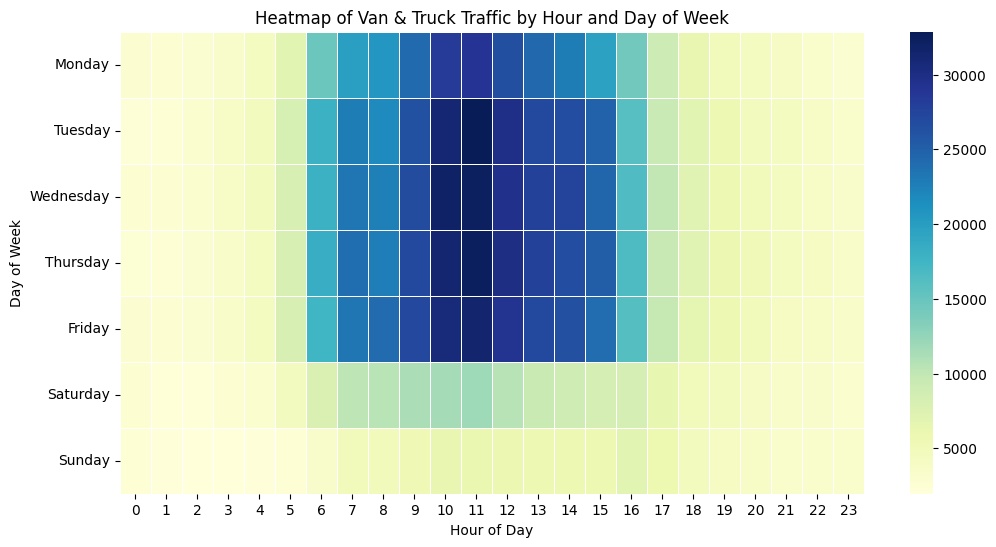

```python
import seaborn as sns
import matplotlib.pyplot as plt

# Pivot table for heatmap
heatmap_data = van_truck_df.pivot_table(
    index="day_of_week", columns="hour", values="vehicle_count", aggfunc="sum"
)

# Reorder days
days_order = ["Monday","Tuesday","Wednesday","Thursday","Friday","Saturday","Sunday"]
heatmap_data = heatmap_data.reindex(days_order)

plt.figure(figsize=(12,6))
sns.heatmap(heatmap_data, cmap="YlGnBu", linewidths=.5)
plt.title("Heatmap of Van & Truck Traffic by Hour and Day of Week")
plt.xlabel("Hour of Day")
plt.ylabel("Day of Week")
plt.show()
```

**Key Insights — Delivery Demand by Hour and Day**

Peak Delivery Hours (Weekdays) Delivery demand is highest between 9 AM and 2 PM from Monday to Friday, with the most intense activity occurring around 10 AM to 12 PM. This indicates that most logistics operations are concentrated during late morning hours.

Midweek Demand is Highest Tuesday, Wednesday, and Thursday show the highest overall traffic intensity, suggesting these are the busiest days for delivery operations.

Lower Demand on Weekends Both Saturday and Sunday exhibit significantly lower traffic levels across all hours, indicating reduced logistics activity compared to weekdays.

Early Morning and Late Night Are Quiet Delivery demand is minimal during late night (8 PM – 5 AM) and early morning hours, suggesting these are low-activity periods in the transport network.

Gradual Build-Up in Morning Traffic begins to increase from around 6 AM, peaks mid-day, and then gradually declines after 3 PM, showing a typical daily logistics cycle.

**Top Locations Analysis — Delivery Demand Hotspots**

Approach:

The dataset is aggregated by location to calculate total vehicle counts. The top 10 locations are selected based on the highest traffic volumes. A horizontal bar chart is used to improve readability of location names.

Interpretation:

This analysis helps city planners and logistics operators identify critical areas that may require traffic management strategies, infrastructure improvements, or optimised delivery scheduling.

[figure not shown]

```python
import matplotlib.pyplot as plt
import seaborn as sns
# Aggregate vehicle counts by location
location_agg = final_df.groupby("location_name", as_index=False)["vehicle_count"].sum()
# Top 10 locations by total traffic
top10_locations = location_agg.sort_values("vehicle_count", ascending=False).head(10)

plt.figure(figsize=(12,6))
sns.barplot(
    data=top10_locations,
    x="vehicle_count",
    y="location_name",
    palette="viridis"
)
plt.title("Top 10 Locations by Van & Truck Traffic")
plt.xlabel("Total Vehicle Count")
plt.ylabel("Location")
plt.show()
```

**Monthly Trend Analysis — Delivery Demand Over Time**

This visualisation illustrates the monthly trends in van and truck traffic, providing insights into how delivery demand changes throughout the year.

Approach:

The data is grouped by year and month, and total vehicle counts are calculated. A line chart is used to compare monthly trends across multiple years, with each year represented by a separate line.

Interpretation:

Peaks in the lines indicate periods of higher delivery demand, which may be influenced by seasonal factors such as holidays or increased commercial activity. Comparing trends across years helps identify consistent seasonal patterns as well as any growth or decline in logistics activity over time.

This analysis supports better planning of delivery operations, resource allocation, and forecasting of future logistics demand.

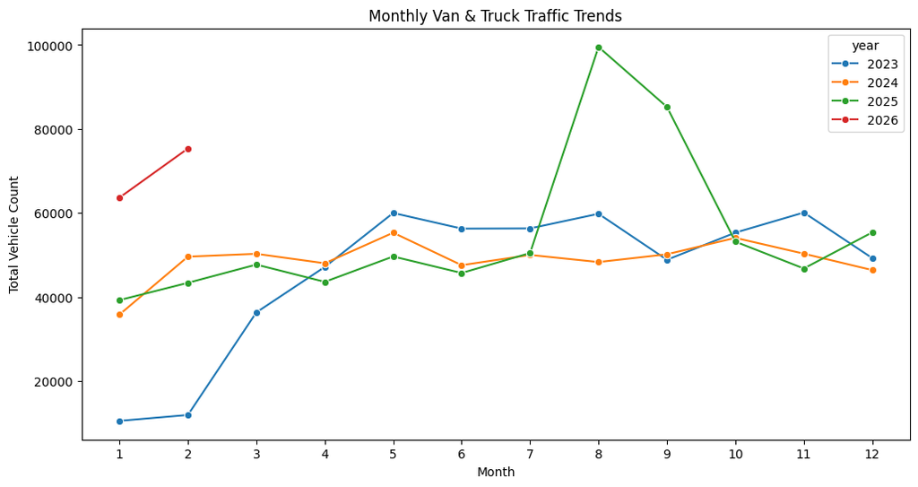

```python
monthly_trend = van_truck_df.groupby(["year", "month"])["vehicle_count"].sum().reset_index()

plt.figure(figsize=(12,6))
sns.lineplot(data=monthly_trend, x="month", y="vehicle_count", hue="year", marker="o", palette="tab10")
plt.title("Monthly Van & Truck Traffic Trends")
plt.xlabel("Month")
plt.ylabel("Total Vehicle Count")
plt.xticks(range(1,13))
plt.show()
```

**Key Insights — Monthly Delivery Demand Trends** Strong Seasonal Spike in 2025 A significant surge in delivery demand is observed in August and September 2025, where vehicle counts sharply increase compared to other months and years. This indicates a major seasonal or event-driven spike in logistics activity.

Stable Patterns in 2024 The year 2024 shows relatively consistent delivery demand across all months, with only minor fluctuations. This suggests a stable and predictable logistics environment during that year.

Growth Trend in Early 2023 In 2023, delivery demand starts low in the early months and increases steadily until mid-year, indicating a recovery or ramp-up in logistics activity.

Higher Demand in Early 2026 The available data for 2026 (first two months) shows higher vehicle counts compared to previous years, suggesting a potential increase in logistics demand continuing into 2026.

**Spatial-Temporal Analysis — Delivery Demand Trends for Top 5 Locations**

This visualisation explores how delivery demand evolves over time at the top 5 busiest locations, providing a combined spatial and temporal perspective.

Approach:

The top 5 locations are identified based on total vehicle counts (highest delivery demand). Data is aggregated on a weekly basis to smooth daily fluctuations. A 5-week rolling average is applied to highlight underlying trends and reduce short-term variability. An interactive line chart is created using Plotly, allowing comparison across locations.

Interpretation:

Each line represents delivery demand trends at a specific location. Parallel trends suggest common, city-wide factors influencing logistics demand. Diverging trends indicate location-specific patterns, such as unique traffic conditions or commercial activity.

This analysis helps determine whether delivery demand behaves consistently across the city or varies by location, supporting more targeted logistics planning and forecasting.

```python
import plotly.express as px
location_agg = van_truck_df.groupby("location_name", as_index=False)["vehicle_count"].sum()
# Identify top 5 busiest locations
top5_locations = location_agg.sort_values("vehicle_count", ascending=False).head(5)["location_name"].tolist()
top5_df = van_truck_df[van_truck_df["location_name"].isin(top5_locations)].copy()

# Weekly aggregation
top5_df['week'] = top5_df['start_time'].dt.to_period('W').apply(lambda r: r.start_time)
weekly_agg = top5_df.groupby(['week', 'location_name'])['vehicle_count'].sum().reset_index()
weekly_agg['rolling_avg'] = weekly_agg.groupby('location_name')['vehicle_count'].transform(lambda x: x.rolling(5, min_periods=1).mean())

# Plot interactive line chart
fig = px.line(
    weekly_agg,
    x="week",
    y="rolling_avg",
    color="location_name",
    markers=True,
    title="Weekly Delivery Demand Trends for Top 5 Locations",
    labels={"rolling_avg":"Vehicle Count (5-week avg)", "week":"Week"}
)
fig.show()
```

[interactive chart not shown]

**Key Insights — Weekly Delivery Demand Trends**

Consistent High Demand at Key Location La Trobe St – William St I-Hub shows significantly higher delivery demand compared to other locations throughout the entire period, indicating it is a major logistics hotspot in the city.

Seasonal Spike in 2025 A sharp increase in delivery demand is observed around mid-to-late 2025 across multiple locations, especially at La Trobe St and Queens Bridge Street. This suggests a city-wide surge, potentially driven by seasonal factors such as peak retail or holiday demand.

Stable vs Volatile Locations Locations like Queens Bridge Street show relatively stable demand with minor fluctuations, indicating consistent traffic flow. In contrast, La Trobe St exhibits higher volatility, suggesting sensitivity to external factors such as events, infrastructure changes, or commercial activity.

Low but Growing Demand Locations Locations such as St Kilda Road and Drummond St have comparatively lower demand but show gradual growth over time, indicating emerging logistics activity in these areas.

### Feature Engineering for Time Series Forecasting

In this step, the dataset is prepared for time series forecasting by aggregating vehicle counts, generating temporal features, and creating lag-based statistics. These engineered features help the model capture traffic trends, seasonality, and temporal dependencies across different locations.

#### 1. Data Aggregation and Sorting

The raw vehicle data is first grouped by:

- `start_time`
- `location_id`
- `latitude`
- `longitude`

The `vehicle_count` values are summed for each combination to obtain the total number of vehicles observed at a specific location and time.

After aggregation, the dataset is sorted by:

1. `location_id`
2. `start_time`

Sorting is critical before generating lag features because time series models require observations to be in chronological order within each location.

#### 2. Time-Based Feature Extraction

Several temporal features are extracted from the `start_time` column to help the model learn recurring traffic patterns:

- **hour** - captures hourly traffic variations
- **day** - captures daily trends within a month
- **month** - captures seasonal effects
- **year** - captures yearly variations
- **dayofweek** - identifies weekday vs. weekend behavior
- **is_weekend** - binary feature indicating weekends (`1`) or weekdays (`0`)

These features allow the forecasting model to detect cyclic traffic patterns such as rush hours and weekend fluctuations.

#### 3. Lag Features

Lag features provide historical context by including previous observations of vehicle counts for the same location.

These features are especially useful in time series forecasting because traffic patterns often depend heavily on recent observations.

The `groupby("location_id")` operation ensures that lag calculations remain isolated within each location, preventing data leakage across different geographic areas.

#### 4. Rolling Mean Features

Rolling averages are used to smooth short-term fluctuations and capture broader traffic trends.

- **rolling_mean_3** - average vehicle count over the previous 3 time steps
- **rolling_mean_24** - average vehicle count over the previous 24 time steps

The rolling calculations are shifted by one step to ensure that only past information is used when predicting future values.

#### 5. Handling Missing Values

Lag and rolling operations naturally create missing values at the beginning of each location’s time series. These rows are removed using `dropna()` to ensure the final dataset contains only complete feature sets suitable for model training.

Finally, the dataset shape and sample rows are displayed to verify successful feature engineering.

```python
import pandas as pd
import numpy as np

# ── 1. Sort globally by time first (critical before lag features) ──────────
forecast_df = (
    van_truck_df
    .groupby(["start_time", "location_id", "latitude", "longitude"], as_index=False)["vehicle_count"]
    .sum()
    .sort_values(["location_id", "start_time"])   # sort within each location
    .reset_index(drop=True)
)

# ── 2. Time features ──────────────────────────────────────────────────────
forecast_df["hour"]      = forecast_df["start_time"].dt.hour
forecast_df["day"]       = forecast_df["start_time"].dt.day
forecast_df["month"]     = forecast_df["start_time"].dt.month
forecast_df["year"]      = forecast_df["start_time"].dt.year
forecast_df["dayofweek"] = forecast_df["start_time"].dt.dayofweek
forecast_df["is_weekend"] = forecast_df["dayofweek"].isin([5, 6]).astype(int)

# ── 3. Lag & rolling features (FIXED: transform keeps group boundaries) ───
forecast_df["lag_1"] = (
    forecast_df.groupby("location_id")["vehicle_count"]
    .transform(lambda x: x.shift(1))
)
forecast_df["lag_24"] = (
    forecast_df.groupby("location_id")["vehicle_count"]
    .transform(lambda x: x.shift(24))          # same hour, previous day
)
forecast_df["rolling_mean_3"] = (
    forecast_df.groupby("location_id")["vehicle_count"]
    .transform(lambda x: x.shift(1).rolling(3, min_periods=1).mean())
)
forecast_df["rolling_mean_24"] = (
    forecast_df.groupby("location_id")["vehicle_count"]
    .transform(lambda x: x.shift(1).rolling(24, min_periods=1).mean())
)

forecast_df = forecast_df.dropna().reset_index(drop=True)
print(f"Dataset shape after feature engineering: {forecast_df.shape}")
print(forecast_df.head())
```

```
Dataset shape after feature engineering: (670604, 15)
                 start_time  location_id   latitude   longitude  \
0 2023-01-08 06:45:00+00:00      43772.0 -37.820176  144.965092
1 2023-01-09 01:50:00+00:00      43772.0 -37.820176  144.965092
2 2023-01-09 01:55:00+00:00      43772.0 -37.820176  144.965092
3 2023-01-09 08:40:00+00:00      43772.0 -37.820176  144.965092
4 2023-01-09 08:55:00+00:00      43772.0 -37.820176  144.965092

   vehicle_count  hour  day  month  year  dayofweek  is_weekend  lag_1  \
0            1.0     6    8      1  2023          6           1    1.0
1            1.0     1    9      1  2023          0           0    1.0
2            1.0     1    9      1  2023          0           0    1.0
3            2.0     8    9      1  2023          0           0    1.0
4            2.0     8    9      1  2023          0           0    2.0

   lag_24  rolling_mean_3  rolling_mean_24
0     1.0        1.333333         1.583333
1     1.0        1.000000         1.583333
2     1.0        1.000000         1.583333
3     2.0        1.000000         1.583333
4     1.0        1.333333         1.583333
```

### Train-Test Split

The dataset is sorted chronologically by `start_time` to preserve the temporal order required for time series forecasting. An 80–20 split is then applied, where the first 80% of observations are used for training and the remaining 20% are used for testing.

Input features include:

- Spatial information (`location_id`, `latitude`, `longitude`)
- Time-based features (`hour`, `day`, `month`, `year`, `dayofweek`, `is_weekend`)
- Historical traffic features (`lag_1`, `lag_24`, `rolling_mean_3`, `rolling_mean_24`)

The target variable is `vehicle_count`.

Finally, the shapes and time ranges of the training and testing datasets are displayed to verify the split.

```python
# Sort globally by time for a clean temporal split
forecast_df = forecast_df.sort_values("start_time").reset_index(drop=True)

split_idx = int(len(forecast_df) * 0.8)
train = forecast_df.iloc[:split_idx]
test  = forecast_df.iloc[split_idx:]

FEATURES = [
    "location_id", "latitude", "longitude",
    "hour", "day", "month", "year", "dayofweek", "is_weekend",
    "lag_1", "lag_24", "rolling_mean_3", "rolling_mean_24"
]
TARGET = "vehicle_count"

X_train, y_train = train[FEATURES], train[TARGET]
X_test,  y_test  = test[FEATURES],  test[TARGET]

print(f"Train: {X_train.shape} | Test: {X_test.shape}")
print(f"Train period: {train['start_time'].min()} - {train['start_time'].max()}")
print(f"Test  period: {test['start_time'].min()}  - {test['start_time'].max()}")
```

```
Train: (536483, 13) | Test: (134121, 13)
Train period: 2023-01-06 07:10:00+00:00 - 2025-08-25 16:35:00+00:00
Test  period: 2025-08-25 16:40:00+00:00  - 2026-02-28 23:55:00+00:00
```

### Model Evaluation Metrics

A custom evaluation function is defined to measure the performance of forecasting models using multiple regression metrics.

The following metrics are calculated:

- **MAE (Mean Absolute Error)**: Measures the average absolute difference between actual and predicted vehicle counts.
- **RMSE (Root Mean Squared Error)**: Penalises larger prediction errors and indicates overall prediction accuracy.
- **R² Score**: Represents how well the model explains the variability in vehicle counts.
- **MAPE (Mean Absolute Percentage Error)**: Measures prediction error as a percentage, making results easier to interpret.

The function prints the evaluation results in a structured format and returns the metrics as a dictionary for further comparison across models.

```python
from sklearn.metrics import mean_absolute_error, mean_squared_error, r2_score

def evaluate(name, y_true, y_pred):
    mae  = mean_absolute_error(y_true, y_pred)
    rmse = np.sqrt(mean_squared_error(y_true, y_pred))
    r2   = r2_score(y_true, y_pred)
    mape = np.mean(np.abs((y_true - y_pred) / (y_true.clip(lower=1)))) * 100

    print(f"\n{'='*45}")
    print(f"  {name}")
    print(f"{'='*45}")
    print(f"  MAE  : {mae:.3f}  vehicles")
    print(f"  RMSE : {rmse:.3f}  vehicles")
    print(f"  R²   : {r2:.4f}  ")
    print(f"  MAPE : {mape:.2f}%")
    return {"model": name, "MAE": mae, "RMSE": rmse, "R2": r2, "MAPE": mape}
```

##### Baseline Forecasting Model

A naive baseline model is implemented using the lag_1 feature, where the predicted vehicle count is assumed to be the same as the previous observation.

This simple approach serves as a reference point for evaluating more advanced forecasting models. The model’s performance is assessed using the previously defined evaluation metrics, and the results are stored for later comparison.

```python
# Predict "same value as the previous observation" — simplest possible model
baseline_pred = test["lag_1"].values
results = []
results.append(evaluate("Naive baseline (lag-1)", y_test, baseline_pred))
```

```
=============================================
  Naive baseline (lag-1)
=============================================
  MAE  : 1.467  vehicles
  RMSE : 2.385  vehicles
  R²   : 0.2130
  MAPE : 55.41%
```

### **XGBoost Forecasting Model**

An XGBoost regression model is trained to predict vehicle counts using the engineered spatial, temporal, and historical traffic features.

The model is configured with:

- Multiple decision trees (`n_estimators`)
- Controlled tree depth (`max_depth`)
- A low learning rate for stable learning
- Subsampling techniques to reduce overfitting
- L1 and L2 regularisation for improved generalisation

After training, predictions are generated on the test dataset and evaluated using the predefined performance metrics.

### Feature Importance Analysis

XGBoost also provides feature importance scores, which indicate how much each feature contributes to the forecasting process.

A bar chart is plotted to visualise the relative importance of all input features, helping identify the most influential factors affecting vehicle count predictions.

```
=============================================
  XGBoost
=============================================
  MAE  : 1.183  vehicles
  RMSE : 1.762  vehicles
  R²   : 0.5707
  MAPE : 50.79%
```

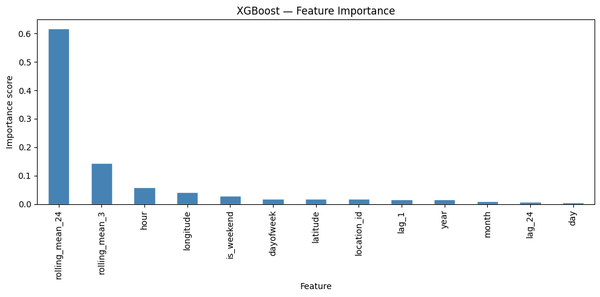

```python
from xgboost import XGBRegressor
import matplotlib.pyplot as plt

xgb_model = XGBRegressor(
    n_estimators=300,
    max_depth=6,
    learning_rate=0.05,
    subsample=0.8,
    colsample_bytree=0.8,
    min_child_weight=3,
    reg_alpha=0.1,         # L1 regularisation
    reg_lambda=1.0,        # L2 regularisation
    random_state=42,
    n_jobs=-1,
    verbosity=0
)

xgb_model.fit(
    X_train, y_train,
    eval_set=[(X_test, y_test)],
    verbose=False
)

xgb_pred = xgb_model.predict(X_test)
results.append(evaluate("XGBoost", y_test, xgb_pred))

# ── Feature importance ────────────────────────────────────────────────────
feat_imp = (
    pd.Series(xgb_model.feature_importances_, index=FEATURES)
    .sort_values(ascending=False)
)

plt.figure(figsize=(10, 5))
feat_imp.plot(kind="bar", color="steelblue", edgecolor="white")
plt.title("XGBoost — Feature Importance")
plt.ylabel("Importance score")
plt.xlabel("Feature")
plt.tight_layout()
plt.show()
```

#### Model Comparison and Prediction Visualisation

The evaluation results of all forecasting models are combined into a DataFrame to enable easy performance comparison across metrics such as MAE, RMSE, R², and MAPE.

To visually assess prediction accuracy, an **Actual vs Predicted** plot is generated using the first 200 samples from the test dataset. The graph compares:

- Actual vehicle counts
- XGBoost predicted values

This visualisation helps evaluate how closely the model follows real traffic patterns and identifies any prediction deviations over time.

```
===== Model Comparison =====
                 model      MAE     RMSE       R2      MAPE
Naive baseline (lag-1) 1.466713 2.384985 0.213013 55.409123
               XGBoost 1.183134 1.761600 0.570651 50.789438
```

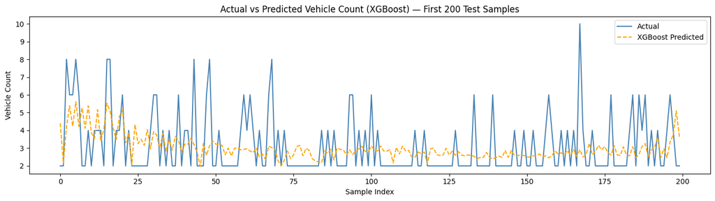

```python
results_df = pd.DataFrame(results)
print("\n===== Model Comparison =====")
print(results_df.to_string(index=False))

import matplotlib.pyplot as plt

sample_idx = range(200)
plt.figure(figsize=(14, 4))
plt.plot(y_test.values[sample_idx], label="Actual", color="steelblue", linewidth=1.5)
plt.plot(xgb_pred[sample_idx],      label="XGBoost Predicted", color="orange", linewidth=1.5, linestyle="--")
plt.title("Actual vs Predicted Vehicle Count (XGBoost) — First 200 Test Samples")
plt.xlabel("Sample Index")
plt.ylabel("Vehicle Count")
plt.legend()
plt.tight_layout()
plt.show()
```

## Residual Analysis

Residual analysis is performed to examine the prediction errors of the XGBoost model. Residuals are calculated as the difference between the actual and predicted vehicle counts.

Two visualisations are generated:

- **Residuals Over Time**: Displays prediction errors for the first 500 test samples, helping identify trends, bias, or unusual error patterns.
- **Residual Distribution Histogram**: Shows the distribution of prediction errors to evaluate whether errors are centered around zero and approximately normally distributed.

This analysis helps assess the reliability and stability of the forecasting model.

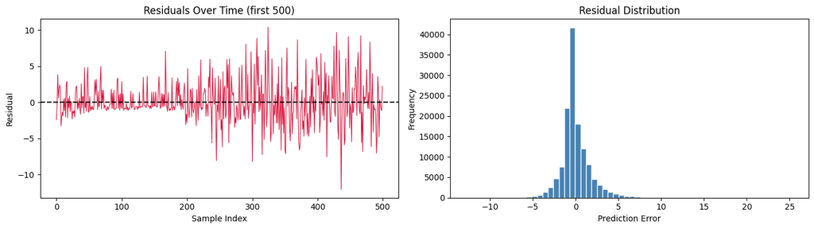

```python
residuals = y_test.values - xgb_pred

fig, axes = plt.subplots(1, 2, figsize=(14, 4))

axes[0].plot(residuals[:500], color="crimson", linewidth=0.8)
axes[0].axhline(0, color="black", linestyle="--")
axes[0].set_title("Residuals Over Time (first 500)")
axes[0].set_xlabel("Sample Index")
axes[0].set_ylabel("Residual")

axes[1].hist(residuals, bins=60, color="steelblue", edgecolor="white")
axes[1].set_title("Residual Distribution")
axes[1].set_xlabel("Prediction Error")
axes[1].set_ylabel("Frequency")

plt.tight_layout()
plt.show()
```

## Future Demand Forecasting

The trained XGBoost model is used to generate a 24-hour vehicle demand forecast for each location.

The forecasting process begins by selecting the most recent observation for every `location_id` as the starting point. Future timestamps are then created hour-by-hour for the next 24 hours.

For each future time step:

- Temporal features such as hour, day, month, and weekend indicators are generated
- Previously known lag and rolling statistics are carried forward as approximate historical inputs

The model predicts future vehicle counts using these generated features, and negative predictions are clipped to zero to maintain realistic values.

Finally:

- A sample of forecasted results is displayed
- A time series plot is created to visualise the predicted vehicle demand over the next 24 hours for a selected location

This step demonstrates how the trained forecasting model can be applied for short-term future demand prediction.

```
===== Sample 24-Hour Forecast =====
    location_id                start_time  predicted_count
0       43772.0 2026-02-28 06:45:00+00:00         1.297010
1       43772.0 2026-02-28 07:45:00+00:00         1.248769
2       43772.0 2026-02-28 08:45:00+00:00         1.217060
3       43772.0 2026-02-28 09:45:00+00:00         1.225578
4       43772.0 2026-02-28 10:45:00+00:00         1.246229
5       43772.0 2026-02-28 11:45:00+00:00         1.244481
6       43772.0 2026-02-28 12:45:00+00:00         1.217684
7       43772.0 2026-02-28 13:45:00+00:00         1.206757
8       43772.0 2026-02-28 14:45:00+00:00         1.206644
9       43772.0 2026-02-28 15:45:00+00:00         1.183699
10      43772.0 2026-02-28 16:45:00+00:00         1.180371
11      43772.0 2026-02-28 17:45:00+00:00         1.120843
12      43772.0 2026-02-28 18:45:00+00:00         1.080515
13      43772.0 2026-02-28 19:45:00+00:00         1.078658
14      43772.0 2026-02-28 20:45:00+00:00         1.077552
15      43772.0 2026-02-28 21:45:00+00:00         1.072954
16      43772.0 2026-02-28 22:45:00+00:00         1.066361
17      43772.0 2026-02-28 23:45:00+00:00         1.063055
18      43772.0 2026-03-01 00:45:00+00:00         1.080353
19      43772.0 2026-03-01 01:45:00+00:00         1.080353
20      43772.0 2026-03-01 02:45:00+00:00         1.105752
21      43772.0 2026-03-01 03:45:00+00:00         1.089688
22      43772.0 2026-03-01 04:45:00+00:00         1.070067
23      43772.0 2026-03-01 05:45:00+00:00         1.102606
```

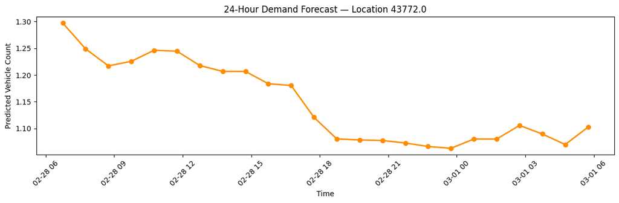

```python
from datetime import timedelta

# Use the last known row per location as the seed
last_known = (
    forecast_df.sort_values("start_time")
    .groupby("location_id")
    .last()
    .reset_index()
)

future_rows = []
for _, row in last_known.iterrows():
    for h in range(1, 25):   # forecast 24 hours ahead
        future_time = row["start_time"] + timedelta(hours=h)
        future_rows.append({
            "location_id":    row["location_id"],
            "latitude":       row["latitude"],
            "longitude":      row["longitude"],
            "start_time":     future_time,
            "hour":           future_time.hour,
            "day":            future_time.day,
            "month":          future_time.month,
            "year":           future_time.year,
            "dayofweek":      future_time.weekday(),
            "is_weekend":     int(future_time.weekday() >= 5),
            # carry forward last known lag values as approximation
            "lag_1":          row["vehicle_count"],
            "lag_24":         row["lag_1"],
            "rolling_mean_3": row["rolling_mean_3"],
            "rolling_mean_24":row["rolling_mean_24"],
        })

future_df = pd.DataFrame(future_rows)
future_df["predicted_count"] = xgb_model.predict(future_df[FEATURES]).clip(min=0)

print("\n===== Sample 24-Hour Forecast =====")
print(future_df[["location_id", "start_time", "predicted_count"]].head(24))

# Plot forecast for one location
loc_sample = future_df["location_id"].iloc[0]
loc_forecast = future_df[future_df["location_id"] == loc_sample]

plt.figure(figsize=(12, 4))
plt.plot(loc_forecast["start_time"], loc_forecast["predicted_count"],
         marker="o", color="darkorange", linewidth=2)
plt.title(f"24-Hour Demand Forecast — Location {loc_sample}")
plt.xlabel("Time")
plt.ylabel("Predicted Vehicle Count")
plt.xticks(rotation=45)
plt.tight_layout()
plt.show()
```

Recommendations: